# Strategic Journal Targeting

Evidence-Based Journal Selection from Recent Publications

Yusri Yusup, Wan Zafira Wan Zakaria, Lee Chee Keong, Norli Ismail, Abdorezza Mohammad Nafchi, Mohd Nurazzi Norizan, Melbi Mahardika

27 July 2026

**Prepared by:** Research Trends Committee 2025, School of Industrial Technology, Universiti Sains Malaysia.

# Executive Summary

This report presents an evidence-based overview of journals in which PPTI academics have successfully published in the last two years. It is intended to support:

- **Strategic journal targeting** for new manuscript submissions
- **Reduction of desk rejections** through scope and outlet alignment
- **Informed publication planning** aligned with PPTI research strengths

This document should be used as a **living reference**, updated periodically to reflect emerging publication trends and shifts in journal performance.

### Report Objective

This report lists journals where PPTI lecturers published within the **last two years**. It serves as a **recommended journal targeting reference** for future manuscript submissions.

**How to use this report**

- Use the search box to find journals quickly.
- Sort by **Total Citations** to identify high-impact outlets.
- Click Scopus links to view the top cited articles.

# Summary

Total Target Journals

309

Total PPTI Contributors

63

Publication Window

Jul 2024 to Jun 2026

# Recommended Journal Target List

## Interpretation Guide

The terms used in this report is defined below.

- **Citations**: Visibility and research influence.
- **Open Access**: Suitable for grant-funded and high-impact dissemination.
- **Publication Count**: Proven PPTI publication success.
- **Scopus Link**: Reference article for targeting and scope matching.

| Journal | Publication_Count | Total_Citations | Open Access | Top_5_Scopus_Links |
| --- | --- | --- | --- | --- |
| International Journal of Biological Macromolecules | 34 | 417 | Open | ScopusScopusScopusScopusScopus |
| Journal of Food Measurement and Characterization | 27 | 158 | Open | ScopusScopusScopusScopusScopus |
| Green Energy and Technology | 22 | 0 | NA | ScopusScopusScopusScopusScopus |
| Polymer Engineering and Science | 17 | 104 | Open | ScopusScopusScopusScopusScopus |
| Solid Waste Management Challenges and Recent Solutions | 12 | 3 | NA | ScopusScopusScopusScopusScopus |
| Biofuels Bioproducts and Biorefining | 11 | 62 | Open | ScopusScopusScopusScopusScopus |
| Bamboo Based Polymer Composites Fundamentals Properties Applications and Performance | 11 | 8 | NA | ScopusScopusScopusScopusScopus |
| Journal of Sustainability Science and Management | 11 | 0 | Open | ScopusScopusScopusScopusScopus |
| Biomass and Bioenergy | 10 | 41 | Open | ScopusScopusScopusScopusScopus |
| Express Polymer Letters | 9 | 40 | Open | ScopusScopusScopusScopusScopus |

[output cut: 299 more lines]

# Top 10 Journals

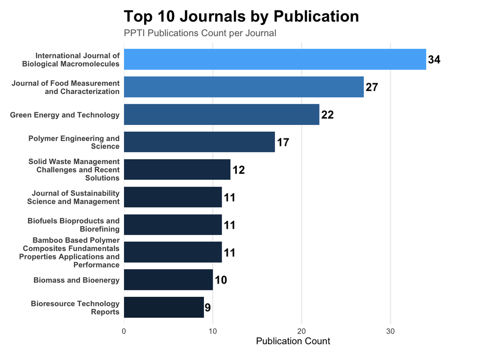